# 36-315 Lab 04

Eu Jing Chua

Due Sep 20 2019 (6:30pm)

Using the tidyverse style guide.

# Problem 1

(5 points each)

**Chi-Square Tests for Independence in `R`**:

```r
library(tidyverse)
library(reshape2)

#  Read in data
airline_tweets <- read_csv("https://raw.githubusercontent.com/mateyneykov/315_code_data/master/data/Tweets.csv")

date_time <- colsplit(airline_tweets$tweet_created, " ", c("date", "time", "zone"))

#  Add start_date variable to airline_tweets, and a bunch of other variables
airline_tweets <- mutate(airline_tweets,
                    start_date = as.Date(date_time$date, format = "%Y-%m-%d"),
                    hour_of_day = as.integer(substr(date_time$time, 1, 2)),
                    am_or_pm = ifelse(hour_of_day < 12, "AM", "PM"),
                    day_of_week = weekdays(start_date),
                    weekend = ifelse(day_of_week %in% c("Saturday", "Sunday"),
                                     "Weekend", "Weekday"),
                    tweet_length = ifelse(nchar(text) > 100, "Long", "Short"))
```

```r
tabla <- with(airline_tweets, table(airline, airline_sentiment))
chisq.test(tabla)
```

```
##
##  Pearson's Chi-squared test
##
## data:  tabla
## X-squared = 1154.028406, df = 10, p-value < 2.220446e-16
```

The test returns the test statistic, the degrees of freedom, and the p-value.  
Test statistic = 1154.0284  
df = 10  
p-value = 2.22e-16

In conclusion, there is enough evidence to reject the null hypothesis that the two variables are independent.

```r
tabla <- with(airline_tweets, table(airline_sentiment, airline))
chisq.test(tabla)
```

```
##
##  Pearson's Chi-squared test
##
## data:  tabla
## X-squared = 1154.028406, df = 10, p-value < 2.220446e-16
```

The results did not change, which makes sense as the chi-square test-statistic does not depend on whether a variable is the row or column, only their counts matter.

```r
tabla <- with(airline_tweets, table(day_of_week, am_or_pm))
chisq.test(tabla)
```

```
##
##  Pearson's Chi-squared test
##
## data:  tabla
## X-squared = 985.5230975, df = 6, p-value < 2.220446e-16
```

We found enough evidence to reject the null hypothesis that `day_of_week` and `am_or_pm` are independent. This makes sense as I can imagine people waking up later on the weekends and hence tending to tweet more in the PM, whereas ppl might tweet at any time of the day on a weekday cause they wake up earlier.

```r
tabla <- with(airline_tweets, table(tweet_length, am_or_pm))
chisq.test(tabla)
```

```
##
##  Pearson's Chi-squared test with Yates' continuity correction
##
## data:  tabla
## X-squared = 0.5549983352, df = 1, p-value = 0.456282539
```

We fail to reject the null hypothesis that tweet length and am or pm are independent. This makes sense as we do not expect tweet lengths to change much because of the time of day, and is rather probably dependent on the person.

# Problem 2

**Mosaic Plots**

```r
library(matrixStats)
```

```r
source("https://raw.githubusercontent.com/mateyneykov/315_code_data/master/code/geom_mosaic.R")
```

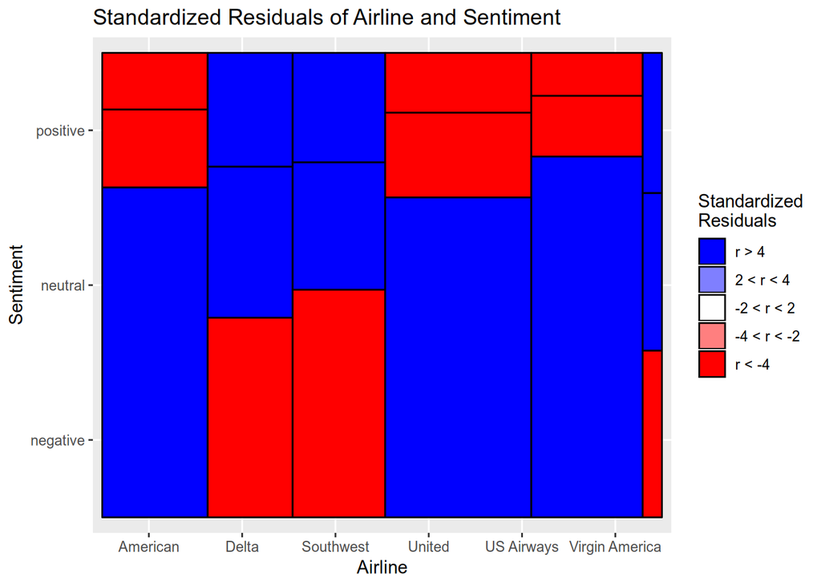

```r
ggplot(airline_tweets, aes(x = airline, y = airline_sentiment)) +
  geom_mosaic() + mosaic_legend() +
  labs(x = "Airline", y = "Sentiment",
       title = "Standardized Residuals of Airline and Sentiment")
```

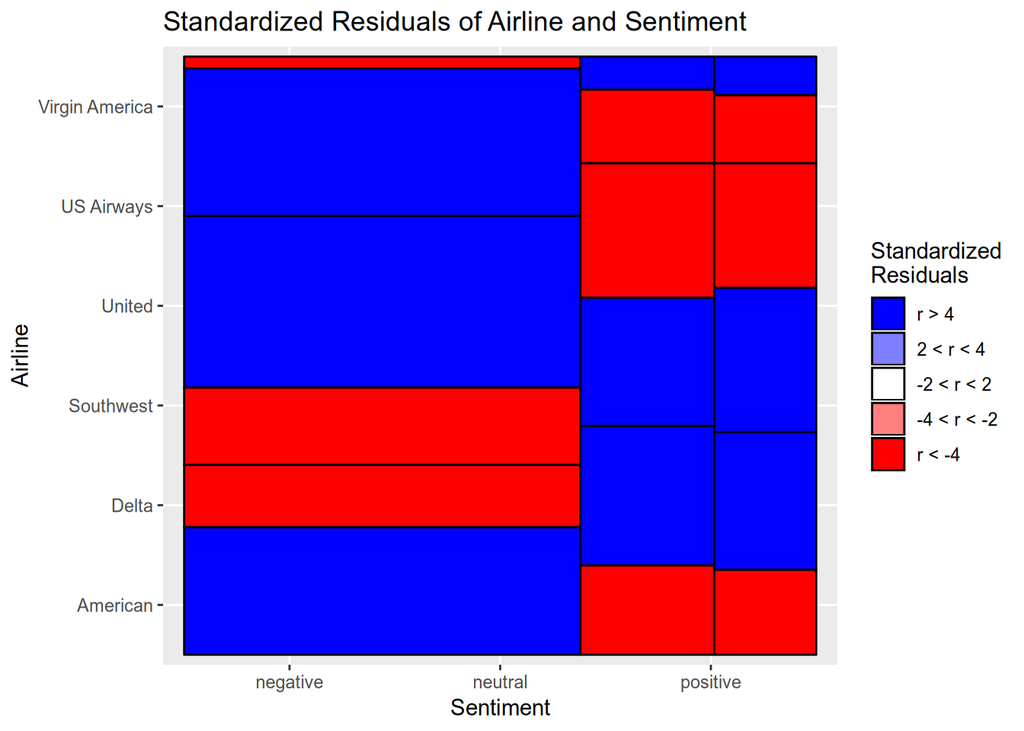

```r
ggplot(airline_tweets, aes(x = airline_sentiment, y = airline)) +
  geom_mosaic() + mosaic_legend() +
  labs(x = "Sentiment", y = "Airline",
       title = "Standardized Residuals of Airline and Sentiment")
```

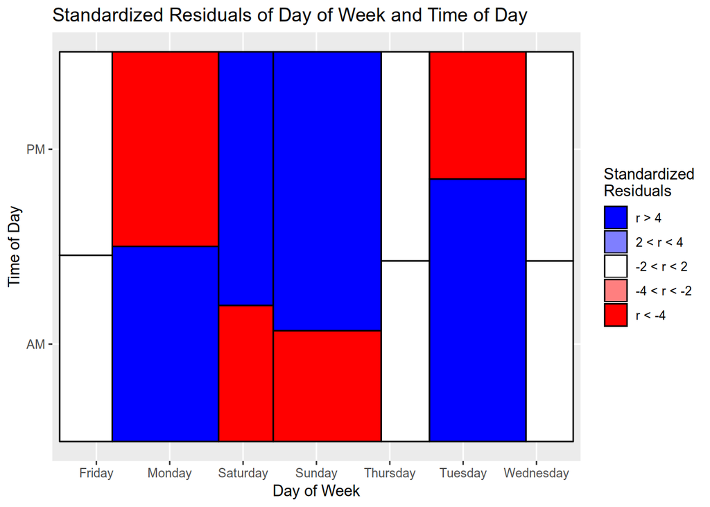

```r
ggplot(airline_tweets, aes(x = day_of_week, y = am_or_pm)) +
  geom_mosaic() + mosaic_legend() +
  labs(x = "Day of Week", y = "Time of Day",
       title = "Standardized Residuals of Day of Week and Time of Day")
```

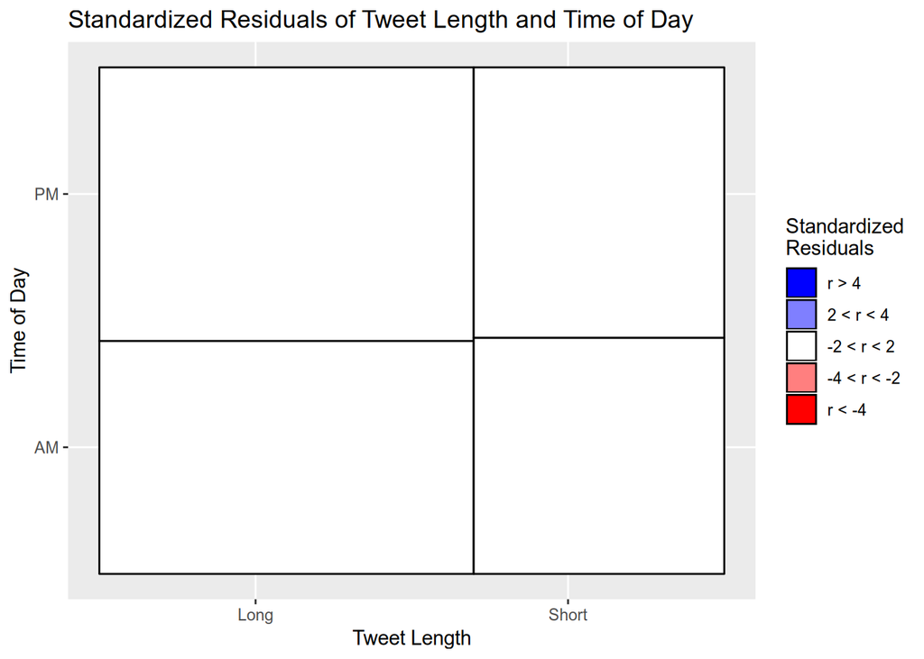

```r
ggplot(airline_tweets, aes(x = tweet_length, y = am_or_pm)) +
  geom_mosaic() + mosaic_legend() +
  labs(x = "Tweet Length", y = "Time of Day",
       title = "Standardized Residuals of Tweet Length and Time of Day")
```

# Problem 3

**Interpretting Mosaic Plots**

1. The mosaic plots yield the same conclusions as the chi-square tests.
2. The widths correspond to the proportion of tweets in that day.
3. The heights correspond to the proportion of tweets in the AM or PM.
4. There are more than expected counts in Monday and Tuesday AM, Saturday and Sunday night, and less than expected counts on Monday and Tuesday PM, Saturday and Sunday AM.

# Problem 4

**Introduction to Continuous Data – Histograms**

1. The data was extracted from the 1974 *Motor Trend* US magazine, and comprises fuel consumption and 10 aspects of automobile design and performance for 32 automobiles (1973-74 models).

   Some continuous variables are the mpg, disp, and hp.

```r
library(datasets)
data(mtcars)
```

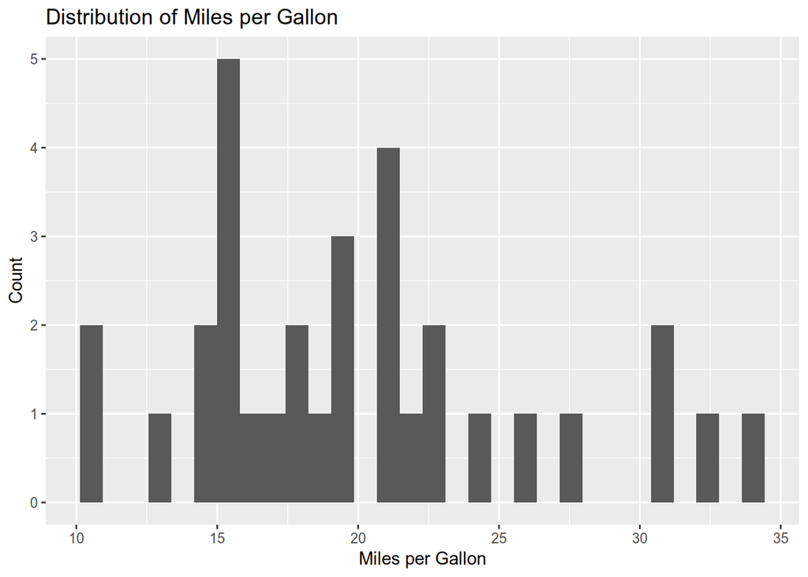

```r
ggplot(mtcars, aes(x = mpg)) +
    geom_histogram() +
    labs(x = "Miles per Gallon",
         y = "Count",
         title = "Distribution of Miles per Gallon")
```

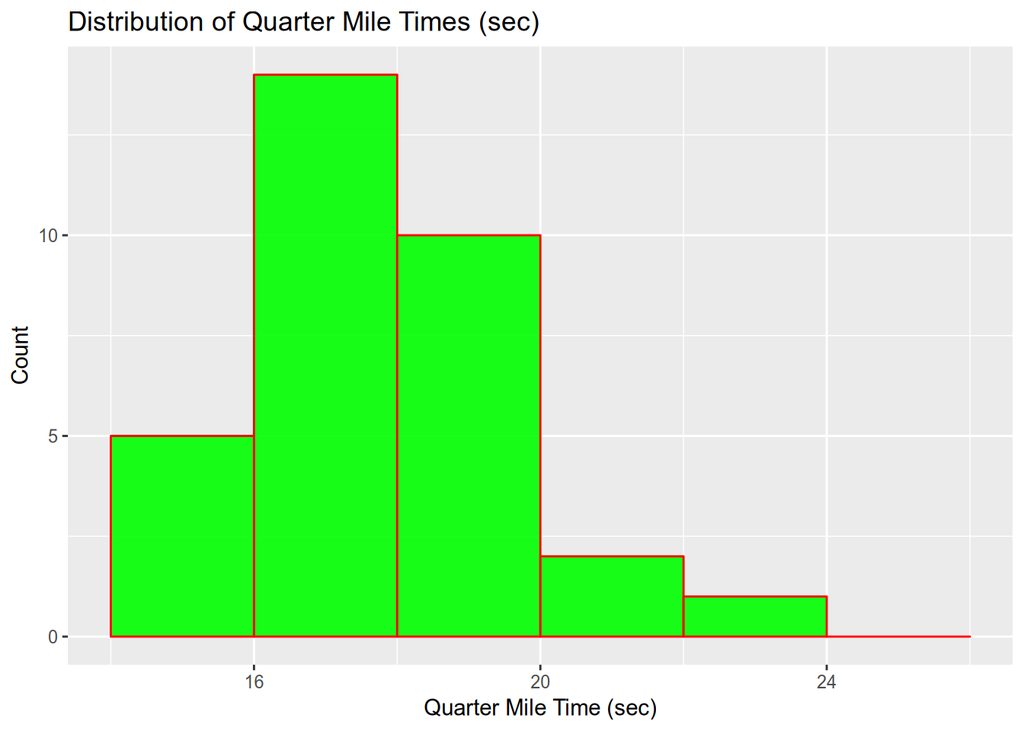

```r
ggplot(mtcars, aes(x = qsec)) +
    geom_histogram(breaks = seq(14, 26, by = 2),
                   col = "red",
                   fill = "green",
                   alpha = 0.9) +
    labs(x = "Quarter Mile Time (sec)",
         y = "Count",
         title = "Distribution of Quarter Mile Times (sec)")
```

There are less bins in that the variable is more discretized.  
Alpha goes from 0 to 1, with lower values being more transparent and higher values being more opaque. The default is 1.0  
The `seq` command creates a sequence of numbers from 14 to 26 in this case, in intervals of 2.

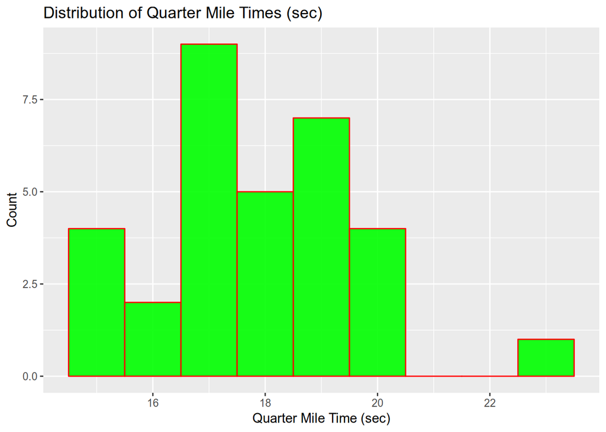

```r
ggplot(mtcars, aes(x = qsec)) +
    geom_histogram(binwidth = 1,
                   col = "red",
                   fill = "green",
                   alpha = 0.9) +
    labs(x = "Quarter Mile Time (sec)",
         y = "Count",
         title = "Distribution of Quarter Mile Times (sec)")
```

This parameter sets the width of each bin, so larger binwidths results in higher discretization.

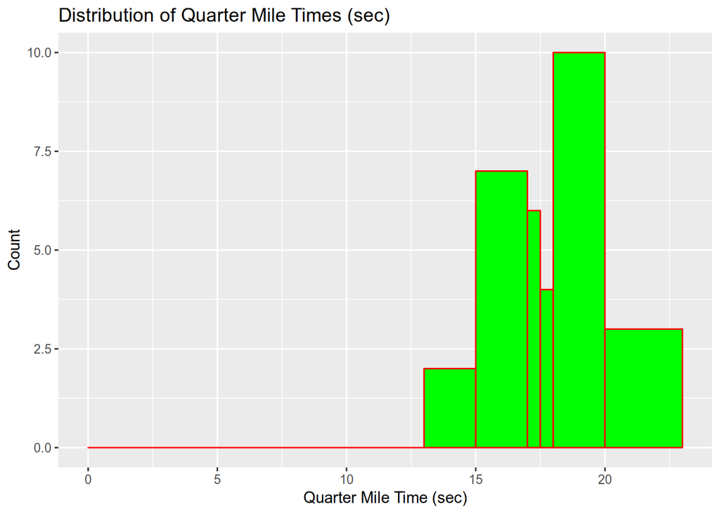

```r
ggplot(mtcars, aes(x = qsec)) +
    geom_histogram(breaks = c(0, 13, 15, 17, 17.5, 18, 20, 23),
                   col = "red",
                   fill = "green") +
    labs(x = "Quarter Mile Time (sec)",
         y = "Count",
         title = "Distribution of Quarter Mile Times (sec)")
```

This graph is hard to interpret accurately due to the varying widths, but we can roughly say that the distribution appears bimodal around 15 and 20 seconds, with a higher proportion of timings around 20 sec compared to 15 secs.